# Regression Analysis for Motor Trend

Eugene Lin

2018-06-26

To see the HTML version (better!), please visit:  
http://rpubs.com/eugenelin89/400270  
For Source Code, please visit:  
https://github.com/eugenelin89/MotorTrend

## Executive Summary

- The investigation considers the Motor Trend US magazine data set to answer the question if transmission makes a difference in vehicle fuel efficiency. The data was extracted from the 1974 Motor Trend US magazine, and comprises fuel consumption and 10 aspects of automobile design and performance for 32 automobiles (1973–74 models).
- Our investigation shows that in general, manual transmission out perofrms automatic transmission in fuel efficiency.
- Other variables also contribute to fuel efficiency, namely: number of cylinders, displacement, gross horsepower, rear axle ratio, weight, and V/S.

## Exploratory Data Analysis

We first take a quick look at what the data set looks like in general. Then, we do a rough calculation of average fuel consumption for manual and automatic transmission independelty. Finally, we take a look at what variables have high correlation to fuel consumption.

```r
# head(mtcars)
mean(mtcars$mpg)
```

```
## [1] 20.09062
```

```r
tapply(mtcars$mpg, mtcars$am, summary)
```

```
## $`0`
##    Min. 1st Qu.  Median    Mean 3rd Qu.    Max.
##   10.40   14.95   17.30   17.15   19.20   24.40
##
## $`1`
##    Min. 1st Qu.  Median    Mean 3rd Qu.    Max.
##   15.00   21.00   22.80   24.39   30.40   33.90
```

```r
cor(mtcars)[1,]
```

```
##        mpg        cyl       disp         hp       drat         wt
##  1.0000000 -0.8521620 -0.8475514 -0.7761684  0.6811719 -0.8676594
##       qsec         vs         am       gear       carb
##  0.4186840  0.6640389  0.5998324  0.4802848 -0.5509251
```

- Mean and Median of manual transmission have better mpg than automatic transmission.
- Figure 1 in Appendix shows that manual transission has better fuel efficiency in general.
- Other variables that have high absolute correlation to mpg are: cyl, disp, hp, drat, wt, vs.

## Model Selection

Based on correlations from Exploratory Data Analysis:  
Pick varables that have absolute correlation higher than 0.6 after rounding to 2 decimal places: cyl, disp, hp, drat, wt, vs, am  
We also fitted only transmission (am) for comparison.

```r
fit <- lm(mpg ~ am + cyl + disp + hp + drat + wt + vs + am, data = df)
fit_am <- lm(mpg ~ am, data = df)
summary(fit)
```

```
##
## Call:
## lm(formula = mpg ~ am + cyl + disp + hp + drat + wt + vs + am,
##     data = df)
##
## Residuals:
##    Min     1Q Median     3Q    Max
## -3.660 -1.678 -0.417  1.371  5.312
##
## Coefficients:
##             Estimate Std. Error t value Pr(>|t|)
## (Intercept) 32.45671    9.02383   3.597  0.00145 **
## am1          1.95201    1.75665   1.111  0.27749
## cyl         -0.63992    0.89674  -0.714  0.48235
## disp         0.01348    0.01212   1.112  0.27695
## hp          -0.03032    0.01469  -2.063  0.05005 .
## drat         0.54696    1.51009   0.362  0.72037
## wt          -3.24531    1.16754  -2.780  0.01041 *
## vs           1.39761    1.84843   0.756  0.45694
## ---
## Signif. codes:  0 '***' 0.001 '**' 0.01 '*' 0.05 '.' 0.1 ' ' 1
##
## Residual standard error: 2.571 on 24 degrees of freedom
## Multiple R-squared:  0.8591, Adjusted R-squared:  0.818
## F-statistic: 20.91 on 7 and 24 DF,  p-value: 9.089e-09
```

```r
summary(fit_am)
```

```
##
## Call:
## lm(formula = mpg ~ am, data = df)
##
## Residuals:
##     Min      1Q  Median      3Q     Max
## -9.3923 -3.0923 -0.2974  3.2439  9.5077
##
## Coefficients:
##             Estimate Std. Error t value Pr(>|t|)
## (Intercept)   17.147      1.125  15.247 1.13e-15 ***
## am1            7.245      1.764   4.106 0.000285 ***
## ---
## Signif. codes:  0 '***' 0.001 '**' 0.01 '*' 0.05 '.' 0.1 ' ' 1
##
## Residual standard error: 4.902 on 30 degrees of freedom
## Multiple R-squared:  0.3598, Adjusted R-squared:  0.3385
## F-statistic: 16.86 on 1 and 30 DF,  p-value: 0.000285
```

Based on the interpretation of coefficients summarized below, including cyl, disp, hp, drat, wt, vs, am is a much better model than transmission (am) alone as they explains 86% of variation as opposed to only 36% when fitted with only transmission.

## Interpreting Coefficients

#### Fitting transmission only:

- mpg for automatic is 17.147, for manual is 17.147 + 7.245.
- R-Squared is 0.3598, approx 36% of the variance explained by transmission.

#### Fitting variables with absolute correlations greater than 0.6

- When fitting with other variables with high absolute correlation, the variables accounts for approx 86% of the variance.
- Putting the varables together, mannual transmission contributes to 1.95 mpg increase in fuel efficiency.

## Conclusion

The better model than considering transmission (am) alone is to also consider the variables cyl, disp, hp, drat, wt, and vs.

#### Is an automatic or manual transmission better for MPG:

Manual transmission is better for MPG.

## Appendix

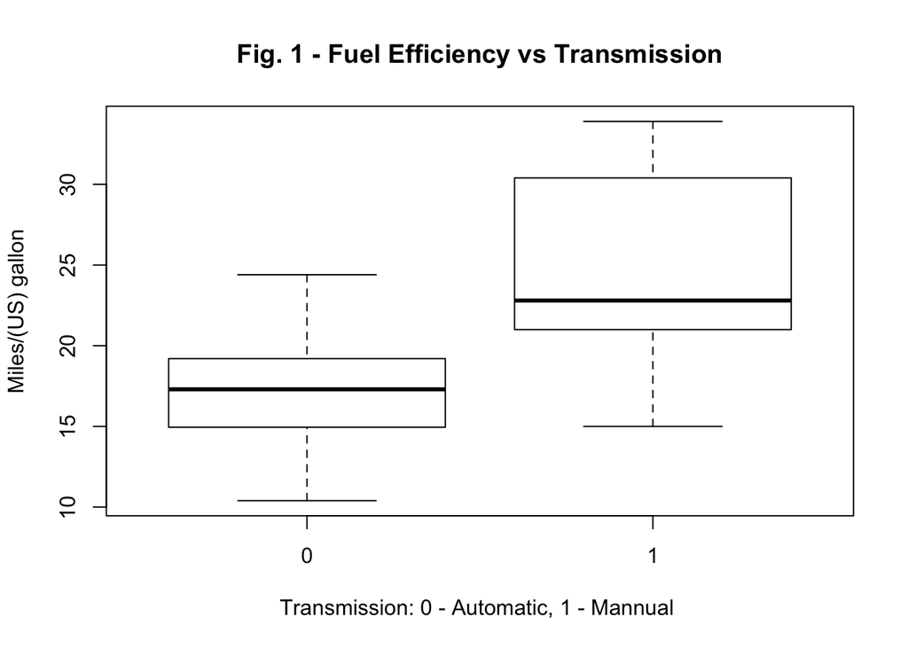

```r
boxplot(mpg ~ am, data = mtcars, ylab='Miles/(US) gallon', xlab='Transmission: 0 - Automatic, 1 - Mannual ', main = 'Fig. 1 - Fuel Efficiency vs Transmission')
```

[figure not shown]

```r
par(mfrow = c(2,2))
plot(fit, main = "Fig. 2 - Regression Diagnistics")
```